# IODS course project

Laura Matkala

# About the course

In this course we learn to use different tools, such as R, R markdown and GitHub. The participants have various backgrounds, but everyone seems to have had somewhat similar aims to attend the course. So, six more weeks of hard work and fun with data are ahead of us before Christmas! I am looking forward to learning all the new things :)

### My Github repository

You can see my GitHub repository here: https://github.com/LauraMatkala/IODS-project

# RStudio Exercise 2: linear regression

### Reading the data in and exploring its structure

The data set that we use for this exercise is about the relationship between learning approaches and students’ achievements in an introductory statistics course in Finland. The set includes students’ age, attitude towards statistics , exam points and gender, as well as their replies to questions related to deep, strategic and surface learning. Likert scale (read more from [here](https://en.wikipedia.org/wiki/Likert_scale)) has been used in answering the questions and measuring the attitude.

The following code reads in the data and gives it a name ‘learning 2014’. The data file has been saved to a local folder earlier.

```r
learning2014<-read.csv(file = "data/learning2014.csv", header = TRUE, sep=",")
```

With the next commands one can check the structure and dimensions of the file with commands str() and dim()

```r
str(learning2014)
```

```
## 'data.frame':    166 obs. of  7 variables:
##  $ Age     : int  53 55 49 53 49 38 50 37 37 42 ...
##  $ Attitude: num  3.7 3.1 2.5 3.5 3.7 3.8 3.5 2.9 3.8 2.1 ...
##  $ Points  : int  25 12 24 10 22 21 21 31 24 26 ...
##  $ gender  : Factor w/ 2 levels "F","M": 1 2 1 2 2 1 2 1 2 1 ...
##  $ deep    : num  3.58 2.92 3.5 3.5 3.67 ...
##  $ stra    : num  3.38 2.75 3.62 3.12 3.62 ...
##  $ surf    : num  2.58 3.17 2.25 2.25 2.83 ...
```

```r
dim(learning2014)
```

```
## [1] 166   7
```

### Graphical overview of data and summaries of variables

Let’s access the libraries of two packages, which are very useful in creating beautiful plots. The packages ‘GGally’ and ‘ggplot2’ have been installed previously.

```r
library(GGally)
```

```r
library(ggplot2)
```

With the help of these packages, one can now use more advanced commands than what are availbale for basic R. Next, I will make a plot matrix, which includes all the variables from the data file.

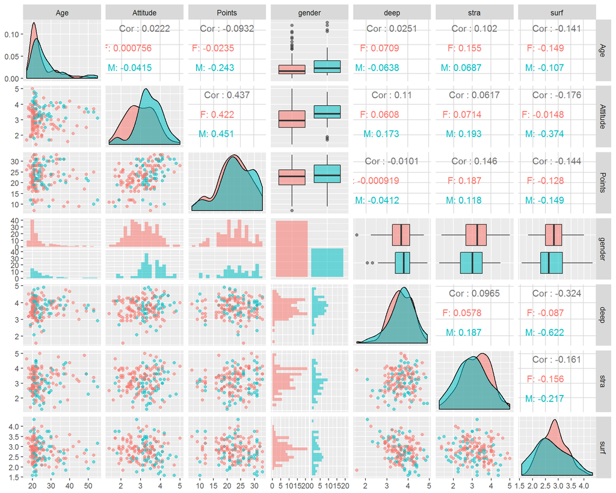

```r
p <- ggpairs(learning2014, mapping = aes(col = gender, alpha = 0.3), lower = list(combo = wrap("facethist", bins = 20)))

p
```

The reddish color to represents female and greenish/blueish represents male in the above plot. It seems that the variables ‘Points’ and ‘Attitude’ correlate with each other the most of all variables. For male this correlation is slightly higher than for female, but the difference is basically non-existent. Gender in general doesn’t make a difference in the amount of points students have gained. Male seem to have a better attitude towards statistics than female on the Likert scale.

What comes to different types of questions, it looks like female have given higher points to surface learning questions then male. Surface learning questions in the questionnaire are related to somehow negative feelings of learning. They include questions like “Often I find myself wondering whether the work I’m doing here is really worthwhile.” or " I often have trouble in making sense of the things I have to remember." On the other hand female also get slightly higher points in questions of strategic learning than male. Strategic learning questions are more positive, such as “I organize my study time carefully to make the best use of it.” or “I’m good at following up some of the reading suggested by lecturers or tutors.”

### Let’s create a model (parts 3 and 4)

In this section I create a linear multiple regression model, which uses Age, Attitude and gender as explanatory variables for ‘Points’. A linear multiple regression model in this case takes the form $y = \alpha+\beta_1x_1+\beta_2x_2+\beta_3x_3+\epsilon$, where Age, Attitude and gender are estimates of $\beta$, $\alpha$ is an intercept and $\epsilon$ is the error term/random noise.

Here is the model:

```r
my_model <- lm(Points ~ Age + Attitude + gender, data = learning2014)
```

And here is the summary of the model:

```r
summary(my_model)
```

```
##
## Call:
## lm(formula = Points ~ Age + Attitude + gender, data = learning2014)
##
## Residuals:
##      Min       1Q   Median       3Q      Max
## -17.4590  -3.3221   0.2186   4.0247  10.4632
##
## Coefficients:
##             Estimate Std. Error t value Pr(>|t|)
## (Intercept) 13.42910    2.29043   5.863 2.48e-08 ***
## Age         -0.07586    0.05367  -1.414    0.159
## Attitude     3.60657    0.59322   6.080 8.34e-09 ***
## genderM     -0.33054    0.91934  -0.360    0.720
## ---
## Signif. codes:  0 '***' 0.001 '**' 0.01 '*' 0.05 '.' 0.1 ' ' 1
##
## Residual standard error: 5.315 on 162 degrees of freedom
## Multiple R-squared:  0.2018, Adjusted R-squared:  0.187
## F-statistic: 13.65 on 3 and 162 DF,  p-value: 5.536e-08
```

This model is trying to minimize the residuals, which are the prediction errors of the model. The best model fit is found so that the sum of the squared residuals is minimized.

The $\beta$ values this model gives us are -0.07, 3.6 and -0.33,respectively, whereas the $\alpha$ (intercept) is 13.4. Standard error for $\alpha$ is 2.29 and for $\beta$s 0.05, 0.59 and 0.92, respectively. If we look at the p-values with a significance level of either 0.05 or 0.01, it seems Attitude is the only one of the chosen explanatory variable that has a statistically significant relationship with Points. The p-value of Attitude is low, only 8.34e-09. Next I will leave out other explanatory variables than Attitude and see if the model improves.

Here is the model:

```r
my_model2 <-lm(Points ~ Attitude, data = learning2014)
```

Let’s see how the summary of the new model looks like:

```r
summary(my_model2)
```

```
##
## Call:
## lm(formula = Points ~ Attitude, data = learning2014)
##
## Residuals:
##      Min       1Q   Median       3Q      Max
## -16.9763  -3.2119   0.4339   4.1534  10.6645
##
## Coefficients:
##             Estimate Std. Error t value Pr(>|t|)
## (Intercept)  11.6372     1.8303   6.358 1.95e-09 ***
## Attitude      3.5255     0.5674   6.214 4.12e-09 ***
## ---
## Signif. codes:  0 '***' 0.001 '**' 0.01 '*' 0.05 '.' 0.1 ' ' 1
##
## Residual standard error: 5.32 on 164 degrees of freedom
## Multiple R-squared:  0.1906, Adjusted R-squared:  0.1856
## F-statistic: 38.61 on 1 and 164 DF,  p-value: 4.119e-09
```

The p-value got smaller, $\alpha$ is now 11.6 and beta 3.52. The standard errors of $\alpha$ and $\beta$ got smaller than in the previous model. If one uses these estimated values of alpha and beta, the form of the model is:

$y = 11.6 + 3.52x+\epsilon$

The biggest interest is in the $\beta$ value. It tells you, that every time x increases by one unit, y increases by 3.52 units. The multiple R-squared for this model is approximately 0.2. This value tells how well the model fits actual data. Low values of R-squared don’t necessarily mean that the model is not working. Human behavior is difficult to predict, so R-squared of 0.2 may actually be quite a good fit.

### Diagnostic plots

Lets’s take a look at a couple of plots, which helps in deciding whether the model works or not. These plots are Residuals vs Fitted values, Normal QQ-plot and Residuals vs Leverage. They all look into different aspects of the error, $\epsilon$, in the model.

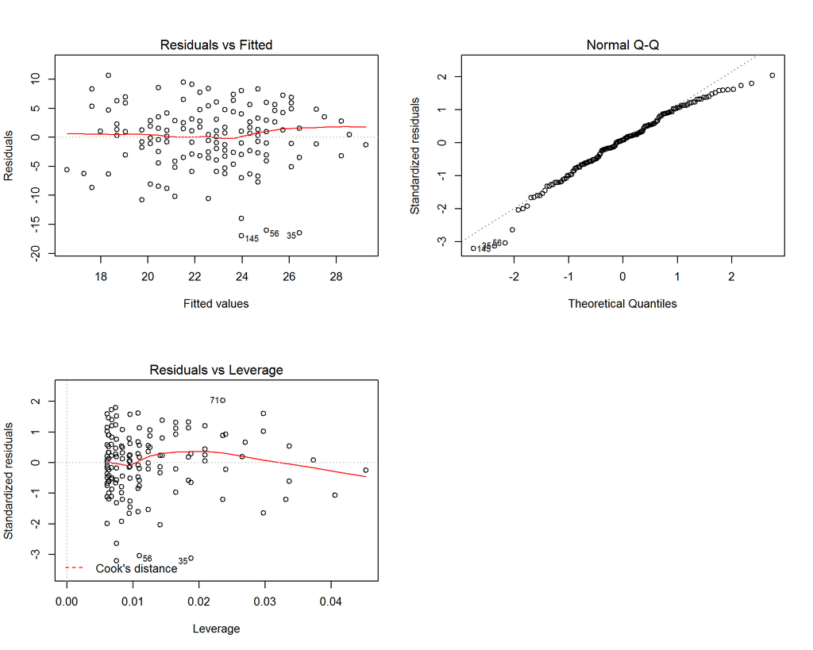

```r
par(mfrow = c(2,2))
plot(my_model2, which = c(1, 2, 5))
```

In order for linear regression models to be valid, assumptions of the $\epsilon$ need to be made.

Residuals vs Fitted values plot deals with the constant variance assumption, which means that the size of the errors should not depend on the explanatory variables. This means that there should be no pattern in the residuals vs fitted plot. If you look at the plot above, it seems that there really is no clear pattern.

The QQ-plot looks at the normality of errors. The errors are assumed to be normally distributed in order to be able to use linear models. The better the data points fall within the straight line drawn in the QQ plot, the better is the fit to the normality assumption. The QQ-plot of my model looks quite ok.

Leverage measures how much impact a single value has on the model. The plot Residuals vs Leverage can help in finding out if some values have an unusually high impact. It looks like there are no single outliers in the plot above.

Overall it looks like the model fits the data reasonably well.

# R studio exercise 3: logistic regression

### Basic information about the data set

In this exercise I use a dataset comprised of datasets of Portuguese students of math and Portuguese language in secondary education. The original datasets can be found from [here](https://archive.ics.uci.edu/ml/datasets/Student+Performance). The following chunks of code read in the dataset from my local folder and print out the names of the variables

```r
alc<-read.csv(file = "data/alc.csv", header = TRUE, sep=",")
colnames(alc)
```

```
##  [1] "school"     "sex"        "age"        "address"    "famsize"
##  [6] "Pstatus"    "Medu"       "Fedu"       "Mjob"       "Fjob"
## [11] "reason"     "nursery"    "internet"   "guardian"   "traveltime"
## [16] "studytime"  "failures"   "schoolsup"  "famsup"     "paid"
## [21] "activities" "higher"     "romantic"   "famrel"     "freetime"
## [26] "goout"      "Dalc"       "Walc"       "health"     "absences"
## [31] "G1"         "G2"         "G3"         "alc_use"    "high_use"
```

**Explanations to the variables**

- “school” = student’s school
- “sex” = student’s sex
- “age” = student’s age
- “address” = student’s home address
- “famsize” = family size
- “Pstatus” = parent’s cohabitation status (living together or apart),
- “Medu” = mother’s education
- “Fedu” = father’s education
- “Mjob” = mother’s job
- “Fjob”= father’s job
- “reason” = reason to choose this school
- “nursery” = attended nursery school (yes or no)
- “internet” = Internet access at home
- “guardian” = student’s guardian (mother, father or other)
- “traveltime” = home to school travel time
- “studytime” = weekly study time
- “failures” = number of past class failures
- “schoolsup” = extra educational support
- “famsup” = family educational support
- “paid” = extra paid classes within the course subject
- “activities” = extra-curricular activities
- “higher” = wants to take higher education
- “romantic” = with a romantic relationship
- “famrel” = quality of family relationships
- “freetime” = free time after school
- “goout” = going out with friends
- “Dalc” = workday alcohol consumption
- “Walc” = weekend alcohol consumption
- “health” = current health status
- “absences” = number of school absences
- “G1” = first period grade
- “G2” = second period grade
- “G3” = final grade
- “alc_use” = average daily alcohol consumption (average of weekday and weekend consumption)
- “high_use” = TRUE is alc_use>2, FALSE if alc_use<2 ([Likert Scale](https://en.wikipedia.org/wiki/Likert_scale))

### Variables chose for the analysis and the hypotheses related to them

I will look into how the students’ alcohol use is related to the variables “sex” (M or F), “Pstatus” (A or T), “guardian” (mother, father or other) and “goout” (Likert scale 1-5). My hypotheses for the chosen variables are, that high use of alcohol is more common for

**1. male than female students,**  
**2. students whose parents live apart, than students whose parents live together**  
**3. students whose guardian is someone else than either of the parents**  
**4. students who go out with friends actively compared to those who don’t**

### Analyses

I will choose only the columns that I need for the analyses and will create a set called alcohol out of them. I need package ‘dplyr’ for this.

```r
library(dplyr)
keep_columns <- c("sex","Pstatus", "guardian", "goout", "high_use")
alcohol <- select(alc, one_of(keep_columns))
```

Next I will graphically examine the variables. The following code draws bar plots of each variable. I will need packages ‘tidyr’, ‘dplyr’ and ‘ggplot2’ for plotting. I have installed the packages beforehand and called ‘dplyr’ already earlier.

```r
library(tidyr)
```

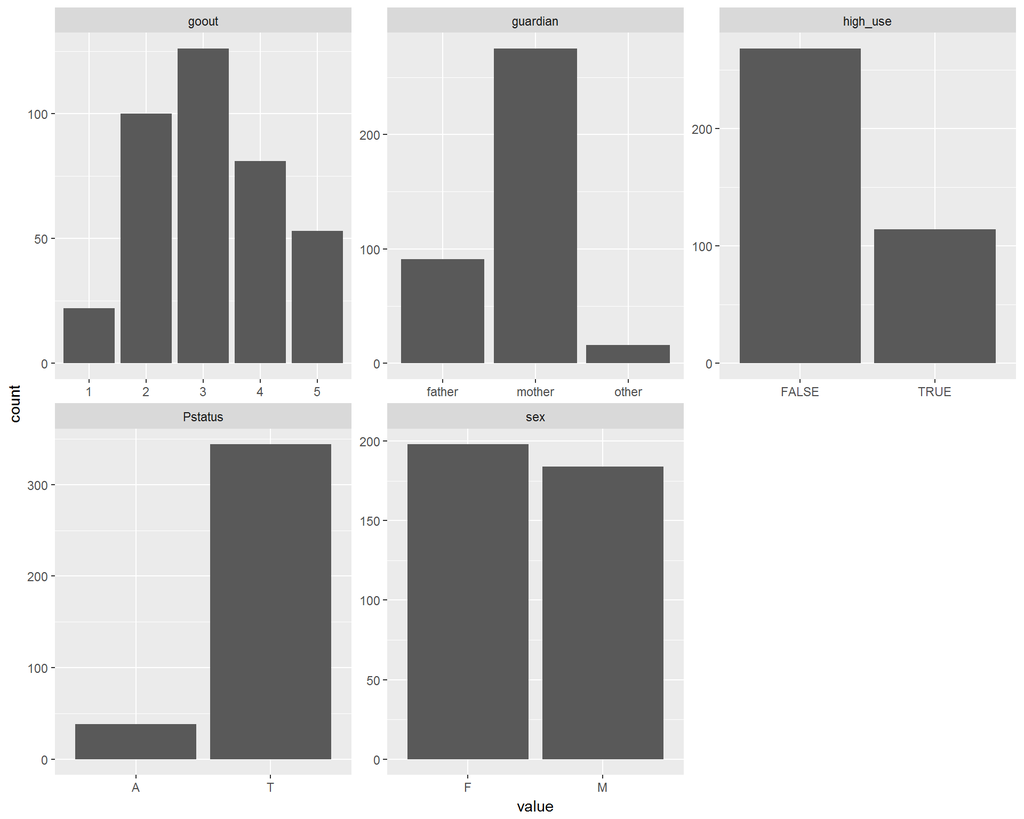

```r
library(ggplot2)
gather(alcohol) %>% ggplot(aes(value)) + facet_wrap("key", scales = "free") + geom_bar()
```

The “goout” variable most often gets the value 3, which is an average value: not very high but not very low either. Mother was the most common guardian for students, followed by father. Some students had marked ‘other’ as guardian. Although high consumption of alcohol also appeared among students, low or normal consumption was more common. Clearly a bigger proportion of students had parents living together than parents living apart, while the gender distribution of students was almost equal.

Next I will examine the relationships between variables by crosstabulation.

```r
table(high_use = alcohol$high_use, sex = alcohol$sex)
```

```
##         sex
## high_use   F   M
##    FALSE 156 112
##    TRUE   42  72
```

```r
table(high_use = alcohol$high_use, Pstatus = alcohol$Pstatus)
```

```
##         Pstatus
## high_use   A   T
##    FALSE  26 242
##    TRUE   12 102
```

```r
table(high_use = alcohol$high_use, guardian = alcohol$guardian)
```

```
##         guardian
## high_use father mother other
##    FALSE     61    198     9
##    TRUE      30     77     7
```

```r
table(high_use = alcohol$high_use, go_out = alcohol$goout)
```

```
##         go_out
## high_use   1   2   3   4   5
##    FALSE  19  84 103  41  21
##    TRUE    3  16  23  40  32
```

To understand what these tables tell I calculated the percentages of students with high alcohol use for each variable statement. The calculations are below.

```r
female_high <- (42/(156+42))*100
female_high
```

```
## [1] 21.21212
```

```r
male_high <-(72/(112+72))*100
male_high
```

```
## [1] 39.13043
```

```r
parents_apart_high <- (12/(26+12))*100
parents_apart_high
```

```
## [1] 31.57895
```

```r
parents_together_high <- (102/(242+102))*100
parents_together_high
```

```
## [1] 29.65116
```

```r
guardian_father_high <- (30/(61+30))*100
guardian_father_high
```

```
## [1] 32.96703
```

```r
guardian_mother_high <- (77/(198+77))*100
guardian_mother_high
```

```
## [1] 28
```

```r
guardian_other_high <- (7/(7+9))*100
guardian_other_high
```

```
## [1] 43.75
```

```r
go_out_1 <- (3/(19+3))*100
go_out_1
```

```
## [1] 13.63636
```

```r
go_out_2 <- (16/(84+16))*100
go_out_2
```

```
## [1] 16
```

```r
go_out_3 <- (23/(103+23))*100
go_out_3
```

```
## [1] 18.25397
```

```r
go_out_4 <- (40/(41+40))*100
go_out_4
```

```
## [1] 49.38272
```

```r
go_out_5 <- (32/(21+32))*100
go_out_5
```

```
## [1] 60.37736
```

Based on these percentages hypothesis number one is supported: 39 % of male students and 21 % of female students use high amounts of alcohol. The percentages for high alcohol use in students whose parents are apart (32 %) versus students whose parents live together (30 %) are almost similar, so hypothesis number two doesn’t seem to be very strongly supported. Hypothesis three is supported, since the amount of high alcohol users when the guardian is other is 44 %, which is clearly higher than when the guardian is father (33 %) or mother (28 %). Also the fourth hypothesis is supported, since the amount of high drinkers clearly increases with the amount of going out. Of course, a more thorough examination is needed, as based on this information it is not possible to tell what differences are statistically significant and what are not.

### Building a logistic regression model

In order to statistically examine the variables and their dependance from each other I am going to use logistic regression and build a model.

```r
m <- glm(high_use ~ sex + Pstatus + guardian + goout, data = alcohol, family = "binomial")
summary(m)
```

```
##
## Call:
## glm(formula = high_use ~ sex + Pstatus + guardian + goout, family = "binomial",
##     data = alcohol)
##
## Deviance Residuals:
##     Min       1Q   Median       3Q      Max
## -1.6778  -0.8245  -0.5846   0.8872   2.3178
##
## Coefficients:
##                Estimate Std. Error z value Pr(>|z|)
## (Intercept)     -3.3914     0.6143  -5.521 3.37e-08 ***
## sexM             0.8576     0.2481   3.457 0.000546 ***
## PstatusT        -0.2189     0.4084  -0.536 0.591942
## guardianmother  -0.3977     0.2920  -1.362 0.173226
## guardianother    0.3346     0.6044   0.554 0.579917
## goout            0.7759     0.1197   6.482 9.03e-11 ***
## ---
## Signif. codes:  0 '***' 0.001 '**' 0.01 '*' 0.05 '.' 0.1 ' ' 1
##
## (Dispersion parameter for binomial family taken to be 1)
##
##     Null deviance: 465.68  on 381  degrees of freedom
## Residual deviance: 399.46  on 376  degrees of freedom
## AIC: 411.46
##
## Number of Fisher Scoring iterations: 4
```

In order to see all coefficients of variable “sex” I will change the model and add -1. This way R will plot all coefficients and no intercept at all.

```r
m <- glm(high_use ~ sex + Pstatus + guardian + goout-1  , data = alcohol, family = "binomial")
summary(m)
```

```
##
## Call:
## glm(formula = high_use ~ sex + Pstatus + guardian + goout - 1,
##     family = "binomial", data = alcohol)
##
## Deviance Residuals:
##     Min       1Q   Median       3Q      Max
## -1.6778  -0.8245  -0.5846   0.8872   2.3178
##
## Coefficients:
##                Estimate Std. Error z value Pr(>|z|)
## sexF            -3.3914     0.6143  -5.521 3.37e-08 ***
## sexM            -2.5338     0.5959  -4.252 2.12e-05 ***
## PstatusT        -0.2189     0.4084  -0.536    0.592
## guardianmother  -0.3977     0.2920  -1.362    0.173
## guardianother    0.3346     0.6044   0.554    0.580
## goout            0.7759     0.1197   6.482 9.03e-11 ***
## ---
## Signif. codes:  0 '***' 0.001 '**' 0.01 '*' 0.05 '.' 0.1 ' ' 1
##
## (Dispersion parameter for binomial family taken to be 1)
##
##     Null deviance: 529.56  on 382  degrees of freedom
## Residual deviance: 399.46  on 376  degrees of freedom
## AIC: 411.46
##
## Number of Fisher Scoring iterations: 4
```

It seems that the coefficients of “sex” are statistically significantly different from zero, which is what the Wald test in R tests for factorial variables ([ref.](https://stats.stackexchange.com/questions/60817/significance-of-categorical-predictor-in-logistic-regression)).

I noticed that R only prints all coefficients of the first factorial variable, which comes after ~ symbol in the code. I am not sure if there is a prettier way of doing this, but in order to see all coefficients of the factorial variables " sex“,”Pstatus" and “guardian”, I will create different models so that I just simply change the order of variables after ~ in the code. I will later also check the overall meaning of each factorial variable to the model. The variable “goout” is an integer, and I can directly see that it has a low p-value so it seems to be explaining high use of alcohol well. But to start with:

Here I check the coefficients of variable Pstatus:

```r
m3 <- glm(high_use ~  Pstatus + guardian + goout + sex -1, data = alcohol, family = "binomial")
summary(m3)
```

```
##
## Call:
## glm(formula = high_use ~ Pstatus + guardian + goout + sex - 1,
##     family = "binomial", data = alcohol)
##
## Deviance Residuals:
##     Min       1Q   Median       3Q      Max
## -1.6778  -0.8245  -0.5846   0.8872   2.3178
##
## Coefficients:
##                Estimate Std. Error z value Pr(>|z|)
## PstatusA        -3.3914     0.6143  -5.521 3.37e-08 ***
## PstatusT        -3.6103     0.4861  -7.427 1.11e-13 ***
## guardianmother  -0.3977     0.2920  -1.362 0.173226
## guardianother    0.3346     0.6044   0.554 0.579917
## goout            0.7759     0.1197   6.482 9.03e-11 ***
## sexM             0.8576     0.2481   3.457 0.000546 ***
## ---
## Signif. codes:  0 '***' 0.001 '**' 0.01 '*' 0.05 '.' 0.1 ' ' 1
##
## (Dispersion parameter for binomial family taken to be 1)
##
##     Null deviance: 529.56  on 382  degrees of freedom
## Residual deviance: 399.46  on 376  degrees of freedom
## AIC: 411.46
##
## Number of Fisher Scoring iterations: 4
```

The two coefficients of “Pstatus”, ‘apart’ and ‘together’ seem to be statistically significantly different from zero.

Next I will check variable “guardian”.

```r
m4 <- glm(high_use ~ guardian + goout + sex + Pstatus-1, data = alcohol, family = "binomial")
summary(m4)
```

```
##
## Call:
## glm(formula = high_use ~ guardian + goout + sex + Pstatus - 1,
##     family = "binomial", data = alcohol)
##
## Deviance Residuals:
##     Min       1Q   Median       3Q      Max
## -1.6778  -0.8245  -0.5846   0.8872   2.3178
##
## Coefficients:
##                Estimate Std. Error z value Pr(>|z|)
## guardianfather  -3.3914     0.6143  -5.521 3.37e-08 ***
## guardianmother  -3.7891     0.5784  -6.551 5.72e-11 ***
## guardianother   -3.0569     0.7644  -3.999 6.36e-05 ***
## goout            0.7759     0.1197   6.482 9.03e-11 ***
## sexM             0.8576     0.2481   3.457 0.000546 ***
## PstatusT        -0.2189     0.4084  -0.536 0.591942
## ---
## Signif. codes:  0 '***' 0.001 '**' 0.01 '*' 0.05 '.' 0.1 ' ' 1
##
## (Dispersion parameter for binomial family taken to be 1)
##
##     Null deviance: 529.56  on 382  degrees of freedom
## Residual deviance: 399.46  on 376  degrees of freedom
## AIC: 411.46
##
## Number of Fisher Scoring iterations: 4
```

And yes, ‘father’, ‘mother’ and ‘other’ all seem to be significantly different from zero.

The fact that all the coeffiecients that I tested above are different from zero mean that the variables are probably not completely meaningless to the model. In order to test that I will now perform a likelihood ratio test so, that I separately test the model with and without each of the factorial varibale.

First I check variable “sex”

```r
m1<-glm(high_use ~ sex + Pstatus + guardian + goout, data = alcohol, family = "binomial")
m2<-glm(high_use ~ Pstatus + guardian + goout, data = alcohol, family = "binomial")
anova(m1, m2, test="LRT")
```

```
## Analysis of Deviance Table
##
## Model 1: high_use ~ sex + Pstatus + guardian + goout
## Model 2: high_use ~ Pstatus + guardian + goout
##   Resid. Df Resid. Dev Df Deviance  Pr(>Chi)
## 1       376     399.46
## 2       377     411.75 -1  -12.286 0.0004564 ***
## ---
## Signif. codes:  0 '***' 0.001 '**' 0.01 '*' 0.05 '.' 0.1 ' ' 1
```

The likelihood ratio test is highly significant, meaning that the variable “sex” should be kept in the model. Next I test the meaning of variable “Pstatus”

```r
m1<-glm(high_use ~  Pstatus + guardian + goout + sex -1, data = alcohol, family = "binomial")
m2<-glm(high_use ~ guardian + goout + sex, data = alcohol, family = "binomial")
anova(m1, m2, test="LRT")
```

```
## Analysis of Deviance Table
##
## Model 1: high_use ~ Pstatus + guardian + goout + sex - 1
## Model 2: high_use ~ guardian + goout + sex
##   Resid. Df Resid. Dev Df Deviance Pr(>Chi)
## 1       376     399.46
## 2       377     399.74 -1 -0.28305   0.5947
```

It looks like “Pstatus” is not a meaningful model parameter. Let’s see if “guardian” is.

```r
m1<-glm(high_use ~ guardian + goout + sex + Pstatus-1, data = alcohol, family = "binomial")
m2<-glm(high_use ~ goout + sex + Pstatus-1, data = alcohol, family = "binomial")
anova(m1, m2, test="LRT")
```

```
## Analysis of Deviance Table
##
## Model 1: high_use ~ guardian + goout + sex + Pstatus - 1
## Model 2: high_use ~ goout + sex + Pstatus - 1
##   Resid. Df Resid. Dev Df Deviance Pr(>Chi)
## 1       376     399.46
## 2       378     402.57 -2  -3.1068   0.2115
```

For modelling purposes “guardian” doesn’t seem to be important either. At the moment it looks like the important explaining variables to be kept in the model are “sex” and “goout”. I will now adjust the model to its final form, show its summary and present its odds ratios

```r
m <- glm(high_use ~ sex + goout, data = alcohol, family ="binomial")
summary(m)
```

```
##
## Call:
## glm(formula = high_use ~ sex + goout, family = "binomial", data = alcohol)
##
## Deviance Residuals:
##     Min       1Q   Median       3Q      Max
## -1.5599  -0.8726  -0.6260   0.8382   2.4893
##
## Coefficients:
##             Estimate Std. Error z value Pr(>|z|)
## (Intercept)  -3.8130     0.4529  -8.420  < 2e-16 ***
## sexM          0.8736     0.2466   3.543 0.000396 ***
## goout         0.7609     0.1181   6.441 1.19e-10 ***
## ---
## Signif. codes:  0 '***' 0.001 '**' 0.01 '*' 0.05 '.' 0.1 ' ' 1
##
## (Dispersion parameter for binomial family taken to be 1)
##
##     Null deviance: 465.68  on 381  degrees of freedom
## Residual deviance: 402.74  on 379  degrees of freedom
## AIC: 408.74
##
## Number of Fisher Scoring iterations: 4
```

```r
OR <- coef(m) %>% exp
CI<-confint(m) %>% exp
cbind(OR, CI)
```

```
##                     OR       2.5 %     97.5 %
## (Intercept) 0.02208168 0.008754964 0.05186666
## sexM        2.39559680 1.484457552 3.91015147
## goout       2.14025612 1.708110942 2.71701439
```

I have trouble in understanding odds ratios. If interpret the last rows of the previous output correctly, if a student is a male, the odds for him to be in using high amount of alcohol is twice as high as if a student is a female. And the confidence intervals mean that in 95 % of the cases the odds are between 1.48 and 3.91. I am even more unsure how to interpret the odds of variable “goout”. I believe it is something like that if a student goes out often and is a male, the odds of the student to be using high amounts of alcohol is about twice as much as for a student who does not go out often. And in 95 % of the cases the odds are between 1.7 and 2.7. I am really struggling with this interpretation, so the odds that I have done something wrong are very high…

### The predictive power of the model

I will now look into the variables “sex” and “goout” that I chose for the model. Next I will provide a 2x2 cross tabulation of predictions versus the actual values.

```r
probabilities <- predict(m, type = "response")
alcohol <- mutate(alcohol, probability = probabilities)
alcohol <- mutate(alcohol, prediction = probability>0.5 )
select(alcohol, sex, goout, high_use, probability, prediction) %>% tail(10)
```

```
##     sex goout high_use probability prediction
## 373   M     2    FALSE  0.19505008      FALSE
## 374   M     3     TRUE  0.34150419      FALSE
## 375   F     3    FALSE  0.17795995      FALSE
## 376   F     3    FALSE  0.17795995      FALSE
## 377   F     2    FALSE  0.09185806      FALSE
## 378   F     4    FALSE  0.31662945      FALSE
## 379   F     2    FALSE  0.09185806      FALSE
## 380   F     1    FALSE  0.04512769      FALSE
## 381   M     5     TRUE  0.70375694       TRUE
## 382   M     1     TRUE  0.10170252      FALSE
```

```r
table(high_use = alcohol$high_use, prediction = alcohol$prediction)
```

```
##         prediction
## high_use FALSE TRUE
##    FALSE   251   17
##    TRUE     63   51
```

I will also compute the training error (the total proportion of inaccurately classified individuals).

```r
loss_func <- function(class, prob) {
  n_wrong <- abs(class - prob) > 0.5
  mean(n_wrong)
}

loss_func(class = alcohol$high_use, prob = alcohol$probability)
```

```
## [1] 0.2094241
```

I would say that the total proportion of inaccurately classified individuals in the predictions that the model does is quite low. Thus, the model is working fairly well.

# Clustering and classification

### The data

This weeks data needs no specific wrangling beforehand, as it comes directly from a package “MASS”. We are using a dataset called Boston, which has variables related to housing in the suburbs of Boston, Massachusettes, USA. The data includes the following columns:

- crim = per capita crime rate by town.
- zn = proportion of residential land zoned for lots over 25,000 sq.ft.
- indus = proportion of non-retail business acres per town.
- chas = Charles River dummy variable (= 1 if tract bounds river; 0 otherwise).
- nox = nitrogen oxides concentration (parts per 10 million).
- rm = average number of rooms per dwelling.
- age = proportion of owner-occupied units built prior to 1940.
- dis = weighted mean of distances to five Boston employment centres.
- rad = index of accessibility to radial highways.
- tax = full-value property-tax rate per $10,000.
- ptratio = pupil-teacher ratio by town.
- black = 1000(Bk - 0.63)^2 where Bk is the proportion of blacks by town.
- lstat = lower status of the population (percent).
- medv = median value of owner-occupied homes in $1000s.

As we can see, there is diverse data related to e.g. the crime rate, air quality (nox) and the proportion of black citizens.

I will explore the data set a bit:

```r
library(MASS)
data("Boston")
str(Boston)
```

```
## 'data.frame':    506 obs. of  14 variables:
##  $ crim   : num  0.00632 0.02731 0.02729 0.03237 0.06905 ...
##  $ zn     : num  18 0 0 0 0 0 12.5 12.5 12.5 12.5 ...
##  $ indus  : num  2.31 7.07 7.07 2.18 2.18 2.18 7.87 7.87 7.87 7.87 ...
##  $ chas   : int  0 0 0 0 0 0 0 0 0 0 ...
##  $ nox    : num  0.538 0.469 0.469 0.458 0.458 0.458 0.524 0.524 0.524 0.524 ...
##  $ rm     : num  6.58 6.42 7.18 7 7.15 ...
##  $ age    : num  65.2 78.9 61.1 45.8 54.2 58.7 66.6 96.1 100 85.9 ...
##  $ dis    : num  4.09 4.97 4.97 6.06 6.06 ...
##  $ rad    : int  1 2 2 3 3 3 5 5 5 5 ...
##  $ tax    : num  296 242 242 222 222 222 311 311 311 311 ...
##  $ ptratio: num  15.3 17.8 17.8 18.7 18.7 18.7 15.2 15.2 15.2 15.2 ...
##  $ black  : num  397 397 393 395 397 ...
##  $ lstat  : num  4.98 9.14 4.03 2.94 5.33 ...
##  $ medv   : num  24 21.6 34.7 33.4 36.2 28.7 22.9 27.1 16.5 18.9 ...
```

```r
dim(Boston)
```

```
## [1] 506  14
```

```r
summary(Boston)
```

```
##       crim                zn             indus            chas
##  Min.   : 0.00632   Min.   :  0.00   Min.   : 0.46   Min.   :0.00000
##  1st Qu.: 0.08204   1st Qu.:  0.00   1st Qu.: 5.19   1st Qu.:0.00000
##  Median : 0.25651   Median :  0.00   Median : 9.69   Median :0.00000
##  Mean   : 3.61352   Mean   : 11.36   Mean   :11.14   Mean   :0.06917
##  3rd Qu.: 3.67708   3rd Qu.: 12.50   3rd Qu.:18.10   3rd Qu.:0.00000
##  Max.   :88.97620   Max.   :100.00   Max.   :27.74   Max.   :1.00000
##       nox               rm             age              dis
##  Min.   :0.3850   Min.   :3.561   Min.   :  2.90   Min.   : 1.130
##  1st Qu.:0.4490   1st Qu.:5.886   1st Qu.: 45.02   1st Qu.: 2.100
##  Median :0.5380   Median :6.208   Median : 77.50   Median : 3.207
##  Mean   :0.5547   Mean   :6.285   Mean   : 68.57   Mean   : 3.795
##  3rd Qu.:0.6240   3rd Qu.:6.623   3rd Qu.: 94.08   3rd Qu.: 5.188
##  Max.   :0.8710   Max.   :8.780   Max.   :100.00   Max.   :12.127
##       rad              tax           ptratio          black
##  Min.   : 1.000   Min.   :187.0   Min.   :12.60   Min.   :  0.32
##  1st Qu.: 4.000   1st Qu.:279.0   1st Qu.:17.40   1st Qu.:375.38
##  Median : 5.000   Median :330.0   Median :19.05   Median :391.44
##  Mean   : 9.549   Mean   :408.2   Mean   :18.46   Mean   :356.67
##  3rd Qu.:24.000   3rd Qu.:666.0   3rd Qu.:20.20   3rd Qu.:396.23
##  Max.   :24.000   Max.   :711.0   Max.   :22.00   Max.   :396.90
##      lstat            medv
##  Min.   : 1.73   Min.   : 5.00
##  1st Qu.: 6.95   1st Qu.:17.02
##  Median :11.36   Median :21.20
##  Mean   :12.65   Mean   :22.53
##  3rd Qu.:16.95   3rd Qu.:25.00
##  Max.   :37.97   Max.   :50.00
```

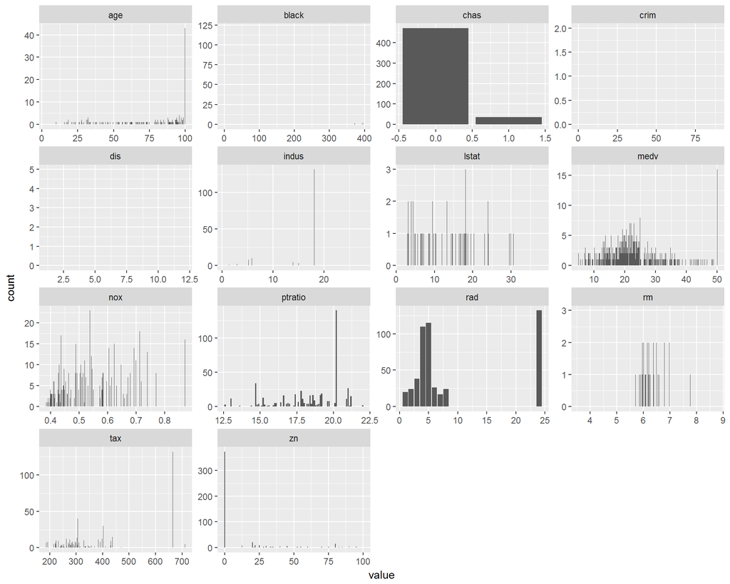

```r
library(corrplot); library(tidyverse);library(ggplot2); library(GGally)
gather(Boston) %>% ggplot(aes(value)) + facet_wrap("key", scales = "free") + geom_bar()
```

```r
cor_matrix<-cor(Boston)
cor_matrix %>% round(digits =2)
```

```
##          crim    zn indus  chas   nox    rm   age   dis   rad   tax
## crim     1.00 -0.20  0.41 -0.06  0.42 -0.22  0.35 -0.38  0.63  0.58
## zn      -0.20  1.00 -0.53 -0.04 -0.52  0.31 -0.57  0.66 -0.31 -0.31
## indus    0.41 -0.53  1.00  0.06  0.76 -0.39  0.64 -0.71  0.60  0.72
## chas    -0.06 -0.04  0.06  1.00  0.09  0.09  0.09 -0.10 -0.01 -0.04
## nox      0.42 -0.52  0.76  0.09  1.00 -0.30  0.73 -0.77  0.61  0.67
## rm      -0.22  0.31 -0.39  0.09 -0.30  1.00 -0.24  0.21 -0.21 -0.29
## age      0.35 -0.57  0.64  0.09  0.73 -0.24  1.00 -0.75  0.46  0.51
## dis     -0.38  0.66 -0.71 -0.10 -0.77  0.21 -0.75  1.00 -0.49 -0.53
## rad      0.63 -0.31  0.60 -0.01  0.61 -0.21  0.46 -0.49  1.00  0.91
## tax      0.58 -0.31  0.72 -0.04  0.67 -0.29  0.51 -0.53  0.91  1.00
## ptratio  0.29 -0.39  0.38 -0.12  0.19 -0.36  0.26 -0.23  0.46  0.46
## black   -0.39  0.18 -0.36  0.05 -0.38  0.13 -0.27  0.29 -0.44 -0.44
## lstat    0.46 -0.41  0.60 -0.05  0.59 -0.61  0.60 -0.50  0.49  0.54
## medv    -0.39  0.36 -0.48  0.18 -0.43  0.70 -0.38  0.25 -0.38 -0.47
##         ptratio black lstat  medv
## crim       0.29 -0.39  0.46 -0.39
## zn        -0.39  0.18 -0.41  0.36
## indus      0.38 -0.36  0.60 -0.48
## chas      -0.12  0.05 -0.05  0.18
## nox        0.19 -0.38  0.59 -0.43
## rm        -0.36  0.13 -0.61  0.70
## age        0.26 -0.27  0.60 -0.38
## dis       -0.23  0.29 -0.50  0.25
## rad        0.46 -0.44  0.49 -0.38
## tax        0.46 -0.44  0.54 -0.47
## ptratio    1.00 -0.18  0.37 -0.51
## black     -0.18  1.00 -0.37  0.33
## lstat      0.37 -0.37  1.00 -0.74
## medv      -0.51  0.33 -0.74  1.00
```

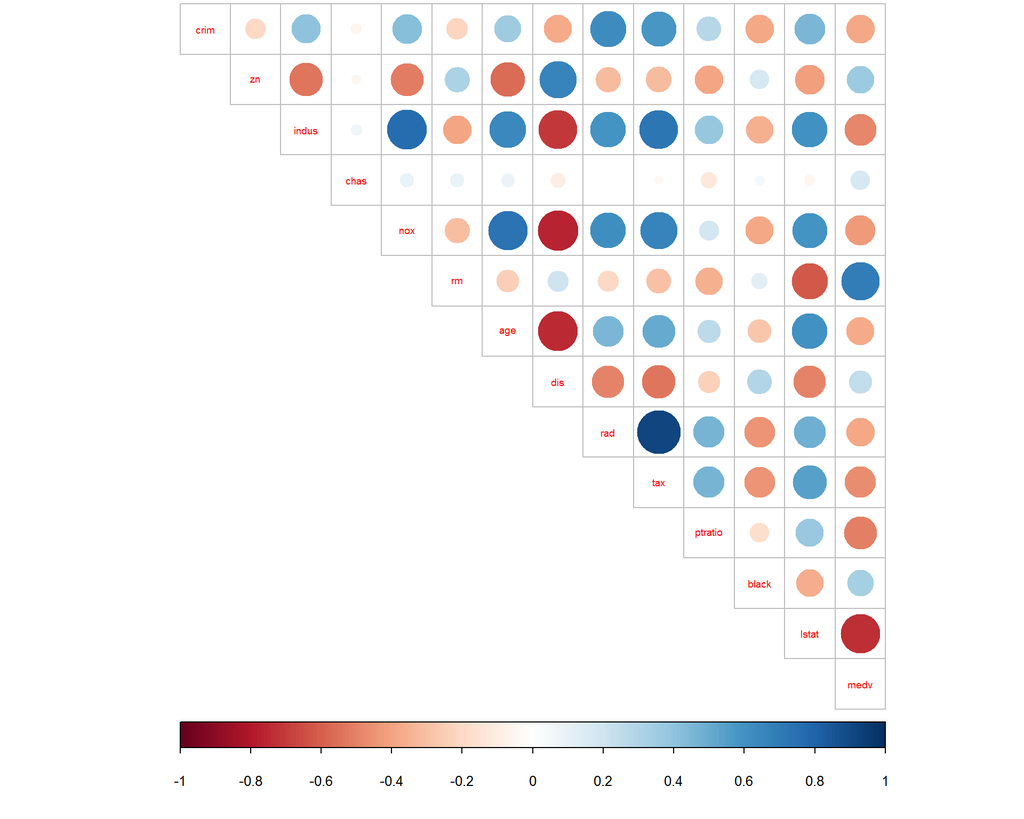

```r
corrplot(cor_matrix, method="circle", type ="upper", cl.pos = "b", tl.pos ="d", tl.cex = 0.6)
```

### Dataset wrangling

I will next standardize the dataset and print out the summaries to see what standardizing did to the dataset. I will also create a categorical variable of the (scaled) crime rate, as well as replace the old “crim” with the new “crime” adn split the dataset into train and test sets.

```r
boston_scaled <- scale(Boston)
summary(boston_scaled)
```

```
##       crim                 zn               indus
##  Min.   :-0.419367   Min.   :-0.48724   Min.   :-1.5563
##  1st Qu.:-0.410563   1st Qu.:-0.48724   1st Qu.:-0.8668
##  Median :-0.390280   Median :-0.48724   Median :-0.2109
##  Mean   : 0.000000   Mean   : 0.00000   Mean   : 0.0000
##  3rd Qu.: 0.007389   3rd Qu.: 0.04872   3rd Qu.: 1.0150
##  Max.   : 9.924110   Max.   : 3.80047   Max.   : 2.4202
##       chas              nox                rm               age
##  Min.   :-0.2723   Min.   :-1.4644   Min.   :-3.8764   Min.   :-2.3331
##  1st Qu.:-0.2723   1st Qu.:-0.9121   1st Qu.:-0.5681   1st Qu.:-0.8366
##  Median :-0.2723   Median :-0.1441   Median :-0.1084   Median : 0.3171
##  Mean   : 0.0000   Mean   : 0.0000   Mean   : 0.0000   Mean   : 0.0000
##  3rd Qu.:-0.2723   3rd Qu.: 0.5981   3rd Qu.: 0.4823   3rd Qu.: 0.9059
##  Max.   : 3.6648   Max.   : 2.7296   Max.   : 3.5515   Max.   : 1.1164
##       dis               rad               tax             ptratio
##  Min.   :-1.2658   Min.   :-0.9819   Min.   :-1.3127   Min.   :-2.7047
##  1st Qu.:-0.8049   1st Qu.:-0.6373   1st Qu.:-0.7668   1st Qu.:-0.4876
##  Median :-0.2790   Median :-0.5225   Median :-0.4642   Median : 0.2746
##  Mean   : 0.0000   Mean   : 0.0000   Mean   : 0.0000   Mean   : 0.0000
##  3rd Qu.: 0.6617   3rd Qu.: 1.6596   3rd Qu.: 1.5294   3rd Qu.: 0.8058
##  Max.   : 3.9566   Max.   : 1.6596   Max.   : 1.7964   Max.   : 1.6372
##      black             lstat              medv
##  Min.   :-3.9033   Min.   :-1.5296   Min.   :-1.9063
##  1st Qu.: 0.2049   1st Qu.:-0.7986   1st Qu.:-0.5989
##  Median : 0.3808   Median :-0.1811   Median :-0.1449
##  Mean   : 0.0000   Mean   : 0.0000   Mean   : 0.0000
##  3rd Qu.: 0.4332   3rd Qu.: 0.6024   3rd Qu.: 0.2683
##  Max.   : 0.4406   Max.   : 3.5453   Max.   : 2.9865
```

```r
class(boston_scaled)
```

```
## [1] "matrix"
```

```r
boston_scaled<-as.data.frame(boston_scaled)
bins <- quantile(boston_scaled$crim)
crime <- cut(boston_scaled$crim, breaks = bins, include.lowest = TRUE, label=c("low", "med_low", "med_high", "high"))
boston_scaled <- dplyr::select(boston_scaled, -crim)
boston_scaled <- data.frame(boston_scaled, crime)
n <- nrow(boston_scaled)
ind <- sample(n,  size = n * 0.8)
train <- boston_scaled[ind,]
test <- boston_scaled[-ind,]
```

I see that after scaling the values are now much smaller than they were in the non-scaled dataset, often even negative medians and minimum values.

### Linear discriminant analysis

I will next perform a linear discriminant analysis on the dataset “train”.

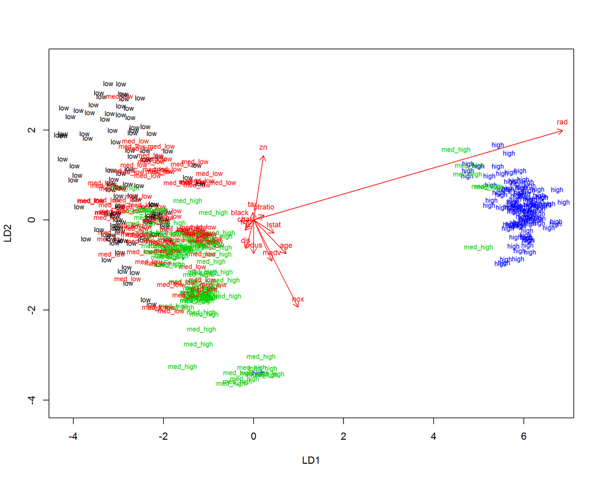

```r
lda.fit <- lda(crime~., data = train)
lda.arrows <- function(x, myscale = 1, arrow_heads = 0.1, color = "red", tex = 0.75, choices = c(1,2)){
  heads <- coef(x)
  arrows(x0 = 0, y0 = 0,
         x1 = myscale * heads[,choices[1]],
         y1 = myscale * heads[,choices[2]], col=color, length = arrow_heads)
  text(myscale * heads[,choices], labels = row.names(heads),
       cex = tex, col=color, pos=3)
}
classes <- as.numeric(train$crime)
plot(lda.fit, dimen = 2, col = classes, pch = classes)
lda.arrows(lda.fit, myscale = 2.3)
```

The plot shows also that with high crime rate variable “rad” is higher. Just to remind ourselves, “rad” equals to index of accessibility to radial highways. I guess it means that with higher index there are better possibilities to access the highway, and thus escape after committing a crime…

I will now save the crime categories and remove the categorical crime variable from the “test” dataset.

```r
correct_classes <- test$crime
test <- dplyr::select(test, -crime)
```

Now I use my LDA model for predicting the classes with the test data and do crosstabulation of the predicted and actual classes from the test data.

```r
lda.pred <- predict(lda.fit, newdata = test)
table(correct = correct_classes, predicted = lda.pred$class)
```

```
##           predicted
## correct    low med_low med_high high
##   low       17       5        2    0
##   med_low    6      14        9    0
##   med_high   0      12       19    0
##   high       0       0        0   18
```

For high quantile the prediction seems to fit with correct values perfectly, as all of the cases could be predicted. All in all, the model is predicting actual cases quite well.

### k-means

Let’s reload the Boston dataset and scale it for some k-means calculations.

```r
library(MASS)
data(Boston)
boston_scaled <- scale(Boston)
class(boston_scaled)
```

```
## [1] "matrix"
```

```r
boston_scaled<-as.data.frame(boston_scaled)
```

I want to calculate the distances between observations and will do that next. I will use Euclidian distances.

```r
dist_eu <- dist(boston_scaled)
summary(dist_eu)
```

```
##    Min. 1st Qu.  Median    Mean 3rd Qu.    Max.
##  0.1343  3.4625  4.8241  4.9111  6.1863 14.3970
```

Now some k-means clustering:

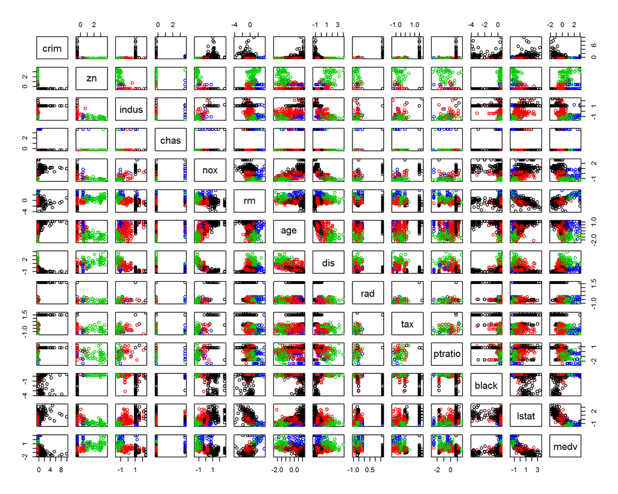

```r
km <-kmeans(boston_scaled, centers = 4)
pairs(boston_scaled, col = km$cluster)
```

The results seem to be similar than they were with LDA, although the figure is rather messy and partially difficult to interpret.

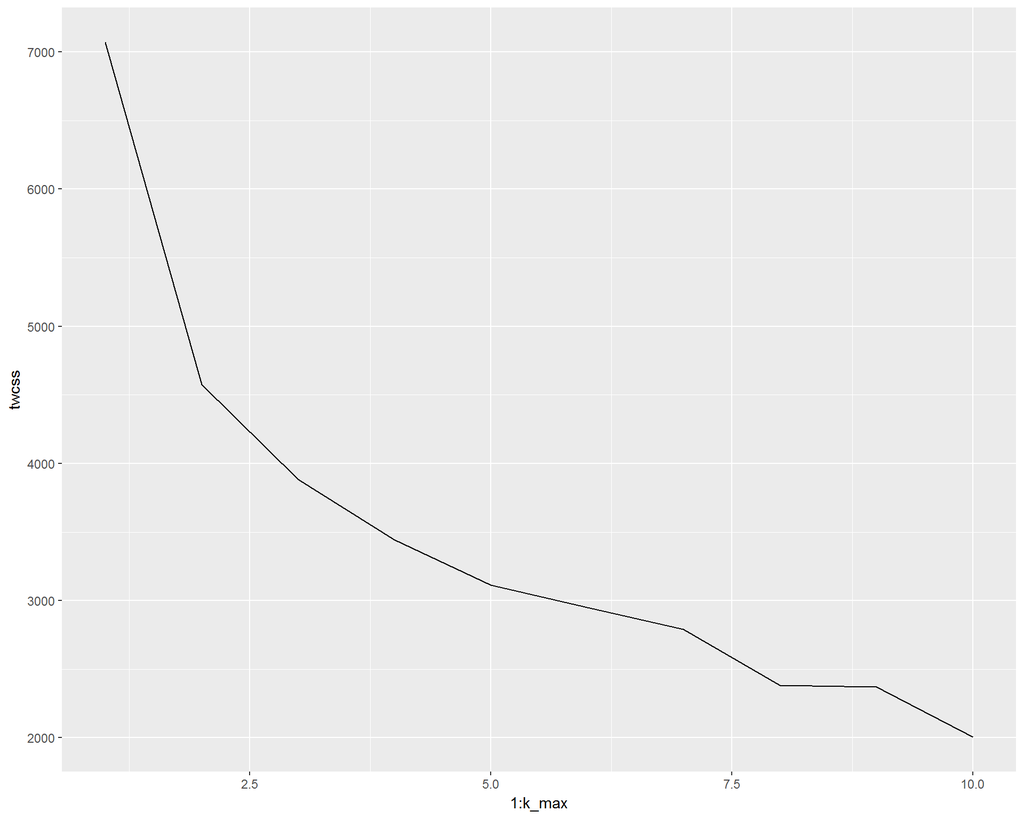

```r
set.seed(123)
k_max <- 10 #
twcss <- sapply(1:k_max, function(k){kmeans(boston_scaled, k)$tot.withinss})
qplot(x = 1:k_max, y = twcss, geom = 'line')
```

# Dimensionality reduction techniques

### Data exploration

This time we are using a dataset from the United Nations Development Programme. The dataset called “human” includes several variables from different countries around the world. Below are the explanations of variables.

- SecoEd_FM = the female to male ratio of having at least secondary education
- LaboFor_FM = the female to male ratio of people in the working force
- ExpEdu = expected years of schooling
- LifeE = life expectancy at birth
- GNI = Gross National Income per capita
- MatMort = maternal mortality ratio
- AdoBirth = Adolescent birth rate
- ParlRep = Percetange of female representatives in parliament

Let’s explore the data a bit now

```r
human <- human <- read.csv(file = "data/human.csv", header = TRUE, sep = ",", row.names = 1)
str(human)
```

```
## 'data.frame':    155 obs. of  8 variables:
##  $ SecoEd_FM : num  1.007 0.997 0.983 0.989 0.969 ...
##  $ LaboFor_FM: num  0.891 0.819 0.825 0.884 0.829 ...
##  $ ExpEdu    : num  17.5 20.2 15.8 18.7 17.9 16.5 18.6 16.5 15.9 19.2 ...
##  $ LifeEx    : num  81.6 82.4 83 80.2 81.6 80.9 80.9 79.1 82 81.8 ...
##  $ GNI       : int  64992 42261 56431 44025 45435 43919 39568 52947 42155 32689 ...
##  $ MatMort   : int  4 6 6 5 6 7 9 28 11 8 ...
##  $ AdoBirth  : num  7.8 12.1 1.9 5.1 6.2 3.8 8.2 31 14.5 25.3 ...
##  $ ParlRep   : num  39.6 30.5 28.5 38 36.9 36.9 19.9 19.4 28.2 31.4 ...
```

```r
dim(human)
```

```
## [1] 155   8
```

```r
library(dplyr)
```

Ok, for some reason GNI is now an integer although I succefully changed it to be numeric….the values still look the same as after I changed it to numeric, so this probably has no effect on anything at all. I will leave it as it is.

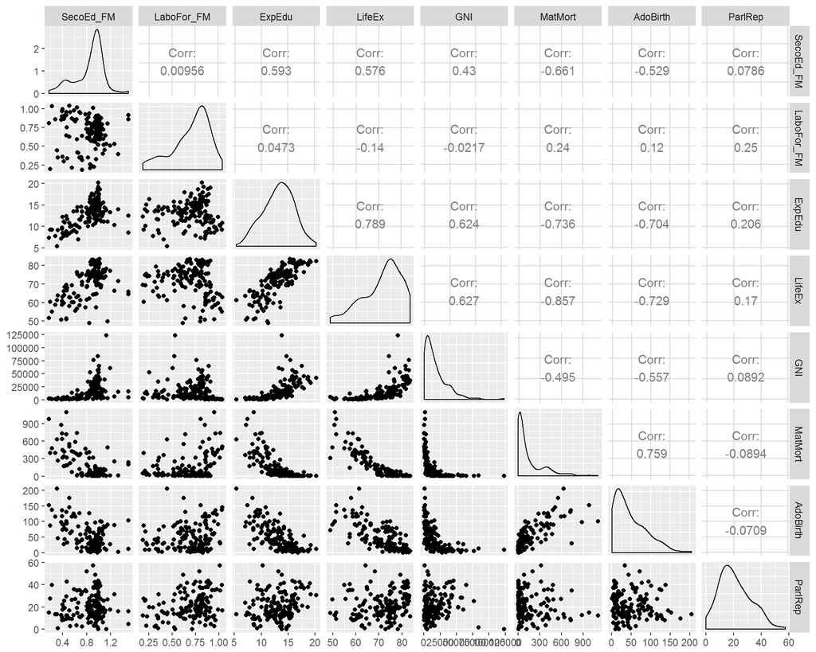

```r
library(ggplot2); library(GGally); library(corrplot)
ggpairs(human)
```

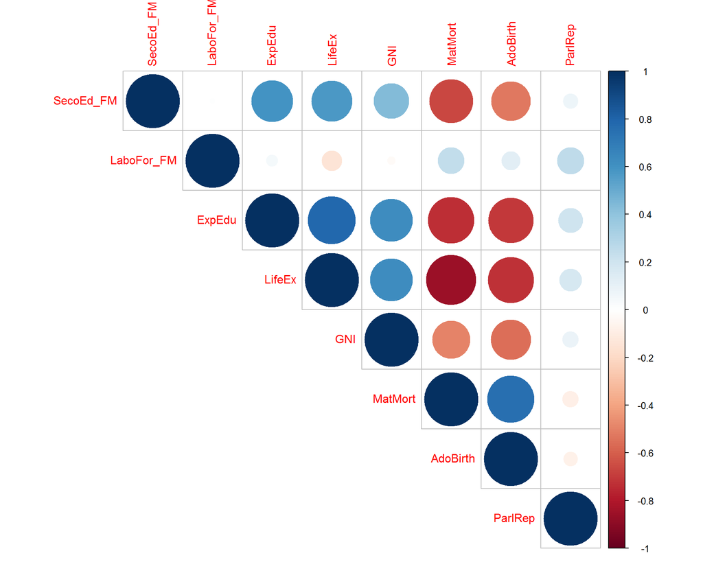

```r
cor(human)%>% corrplot(type = "upper")
```

### Principal Component Analysis (PCA)

Alright, first let’s perform PCA on the non-standardized data

```r
pca_human <- prcomp(human)
s <- summary(pca_human)
s
```

```
## Importance of components%s:
##                              PC1      PC2   PC3   PC4   PC5   PC6    PC7
## Standard deviation     1.854e+04 185.5219 25.19 11.45 3.766 1.566 0.1912
## Proportion of Variance 9.999e-01   0.0001  0.00  0.00 0.000 0.000 0.0000
## Cumulative Proportion  9.999e-01   1.0000  1.00  1.00 1.000 1.000 1.0000
##                           PC8
## Standard deviation     0.1591
## Proportion of Variance 0.0000
## Cumulative Proportion  1.0000
```

```r
pca_pr <- round(1*s$importance[2, ]*100, digits = 1)
pca_pr
```

```
## PC1 PC2 PC3 PC4 PC5 PC6 PC7 PC8
## 100   0   0   0   0   0   0   0
```

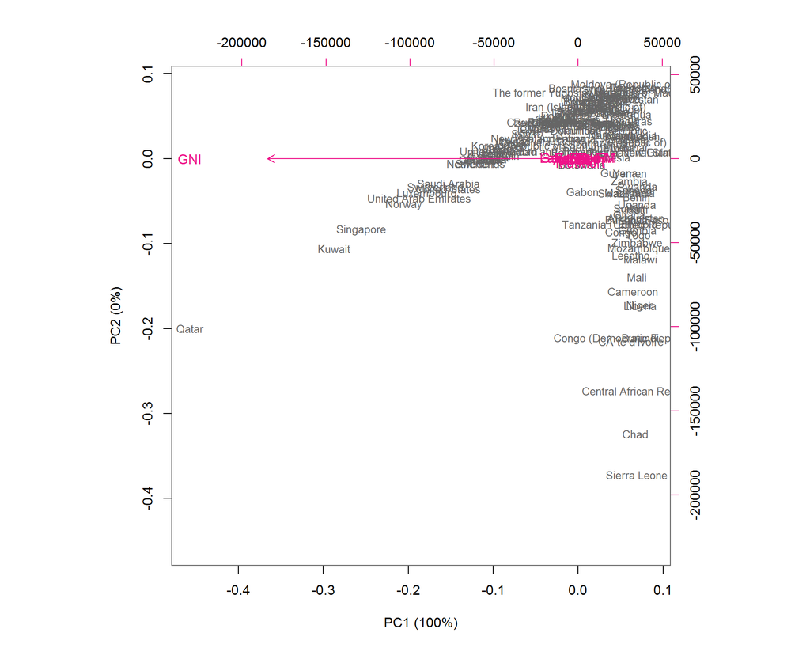

```r
pc_lab<-paste0(names(pca_pr), " (", pca_pr, "%)")
biplot(pca_human, cex = c(0.8, 1), col = c("grey40", "deeppink2"), xlab = pc_lab[1], ylab = pc_lab[2])
```

And next with the standardized data

```r
human_std <- scale(human)
pca_humanstd <- prcomp(human_std)
s <- summary(pca_humanstd)
s
```

```
## Importance of components%s:
##                           PC1    PC2     PC3     PC4     PC5     PC6
## Standard deviation     2.0708 1.1397 0.87505 0.77886 0.66196 0.53631
## Proportion of Variance 0.5361 0.1624 0.09571 0.07583 0.05477 0.03595
## Cumulative Proportion  0.5361 0.6984 0.79413 0.86996 0.92473 0.96069
##                            PC7     PC8
## Standard deviation     0.45900 0.32224
## Proportion of Variance 0.02634 0.01298
## Cumulative Proportion  0.98702 1.00000
```

```r
pca_pr <- round(1*s$importance[2, ]*100, digits = 1)
pca_pr
```

```
##  PC1  PC2  PC3  PC4  PC5  PC6  PC7  PC8
## 53.6 16.2  9.6  7.6  5.5  3.6  2.6  1.3
```

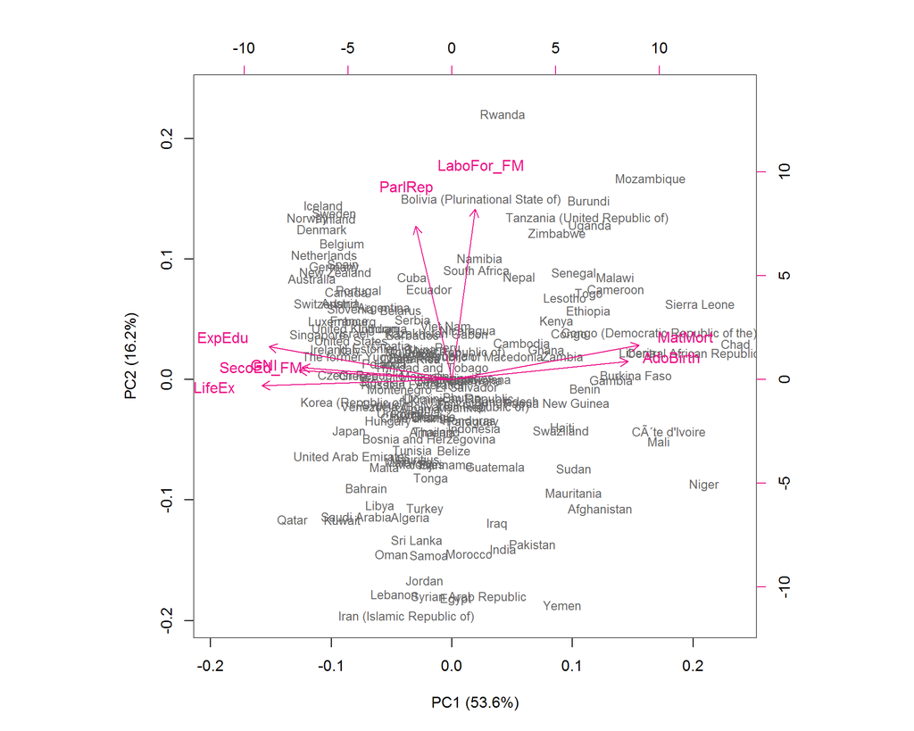

```r
pc_lab<-paste0(names(pca_pr), " (", pca_pr, "%)")
biplot(pca_humanstd, cex = c(0.8, 1), col = c("grey40", "deeppink2"), xlab = pc_lab[1], ylab = pc_lab[2])
```

Clearly the latter figure is more readable than the previous. There were also some zero-length arrows in the PCA of non-standardized data, which led to them being left out completely. The standardization changed the data so that PCA is able to take into account all data there is.

The latter PCA shows that there are differences between variables and their relationships to the principal components. This can be seen by looking at the arrows and their angles towards each other and to the PCs. In the first figure it looks like there are no differences at all, as all the arrows have no angle with the PCs. The smaller the angle is, whether between the different arrows, or the arrow and PC axis, the higher positive correlation there is. So we see that female parliament representation and female/male labour force ratio have quite small correlations with all other variables and also with PC1.

### FactomineR and MCA

```r
library(FactoMineR);library(tidyr)
data("tea")
str(tea)
```

```
## 'data.frame':    300 obs. of  36 variables:
##  $ breakfast       : Factor w/ 2 levels "breakfast","Not.breakfast": 1 1 2 2 1 2 1 2 1 1 ...
##  $ tea.time        : Factor w/ 2 levels "Not.tea time",..: 1 1 2 1 1 1 2 2 2 1 ...
##  $ evening         : Factor w/ 2 levels "evening","Not.evening": 2 2 1 2 1 2 2 1 2 1 ...
##  $ lunch           : Factor w/ 2 levels "lunch","Not.lunch": 2 2 2 2 2 2 2 2 2 2 ...
##  $ dinner          : Factor w/ 2 levels "dinner","Not.dinner": 2 2 1 1 2 1 2 2 2 2 ...
##  $ always          : Factor w/ 2 levels "always","Not.always": 2 2 2 2 1 2 2 2 2 2 ...
##  $ home            : Factor w/ 2 levels "home","Not.home": 1 1 1 1 1 1 1 1 1 1 ...
##  $ work            : Factor w/ 2 levels "Not.work","work": 1 1 2 1 1 1 1 1 1 1 ...
##  $ tearoom         : Factor w/ 2 levels "Not.tearoom",..: 1 1 1 1 1 1 1 1 1 2 ...
##  $ friends         : Factor w/ 2 levels "friends","Not.friends": 2 2 1 2 2 2 1 2 2 2 ...
##  $ resto           : Factor w/ 2 levels "Not.resto","resto": 1 1 2 1 1 1 1 1 1 1 ...
##  $ pub             : Factor w/ 2 levels "Not.pub","pub": 1 1 1 1 1 1 1 1 1 1 ...
##  $ Tea             : Factor w/ 3 levels "black","Earl Grey",..: 1 1 2 2 2 2 2 1 2 1 ...
##  $ How             : Factor w/ 4 levels "alone","lemon",..: 1 3 1 1 1 1 1 3 3 1 ...
```

[output cut: 22 more lines]

```r
dim
```

```
## function (x)  .Primitive("dim")
```

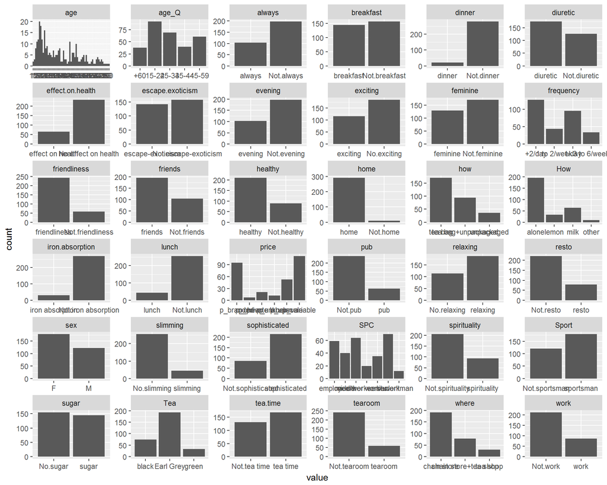

```r
gather(tea) %>% ggplot(aes(value)) + facet_wrap("key", scales = "free") + geom_bar()
```

The figure is a bit messy, but unfortunately I don’t have time now to try to make it clearer. It doesn’t work the same as in datacamp, probably because I have all the variables left here instead of choosing a smaller dataset like in the datacamp examples. Next I will, anyway perform mutliple correspondence analysis on the whole dataset. Let’s see what that’ll look like..

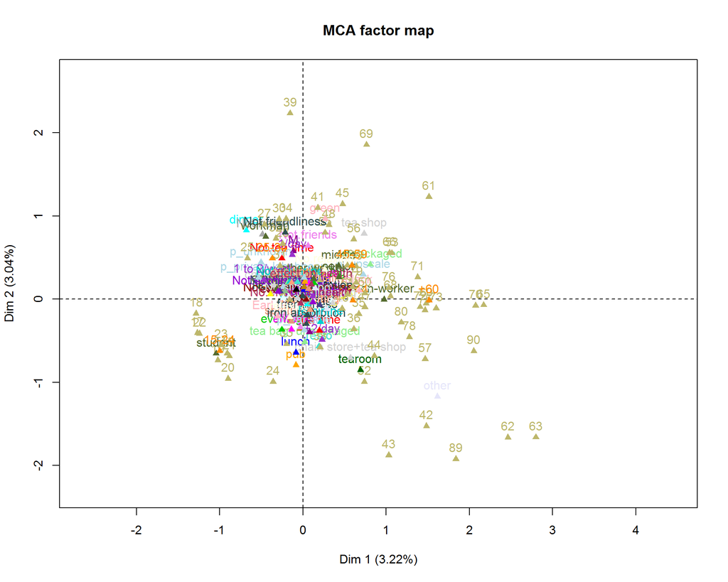

```r
library(stringr)
tea$age <- str_replace(tea$age, pattern=",", replace ="") %>% as.factor() #this changes variable age to a factor, since all variables need to be factors
mca <- MCA(tea, graph = FALSE)
plot(mca, invisible=c("ind"), habillage = "quali")
```

```r
summary(mca)
```

```
##
## Call:
## MCA(X = tea, graph = FALSE)
##
##
## Eigenvalues
##                        Dim.1   Dim.2   Dim.3   Dim.4   Dim.5   Dim.6
## Variance               0.102   0.096   0.085   0.076   0.066   0.065
## % of var.              3.217   3.038   2.686   2.413   2.083   2.063
## Cumulative % of var.   3.217   6.255   8.941  11.353  13.436  15.499
##                        Dim.7   Dim.8   Dim.9  Dim.10  Dim.11  Dim.12
## Variance               0.063   0.060   0.056   0.055   0.052   0.050
## % of var.              2.003   1.890   1.755   1.732   1.651   1.594
## Cumulative % of var.  17.502  19.392  21.147  22.879  24.530  26.124
##                       Dim.13  Dim.14  Dim.15  Dim.16  Dim.17  Dim.18
## Variance               0.049   0.047   0.047   0.046   0.044   0.044
## % of var.              1.542   1.496   1.481   1.444   1.403   1.376
## Cumulative % of var.  27.666  29.162  30.643  32.088  33.491  34.867
##                       Dim.19  Dim.20  Dim.21  Dim.22  Dim.23  Dim.24
## Variance               0.043   0.041   0.040   0.040   0.039   0.039
## % of var.              1.349   1.297   1.266   1.250   1.221   1.218
## Cumulative % of var.  36.216  37.512  38.778  40.028  41.249  42.467
##                       Dim.25  Dim.26  Dim.27  Dim.28  Dim.29  Dim.30
## Variance               0.037   0.037   0.036   0.036   0.035   0.035
## % of var.              1.181   1.155   1.146   1.142   1.115   1.104
## Cumulative % of var.  43.648  44.802  45.948  47.090  48.206  49.310
##                       Dim.31  Dim.32  Dim.33  Dim.34  Dim.35  Dim.36
## Variance               0.035   0.033   0.033   0.033   0.033   0.032
## % of var.              1.090   1.053   1.042   1.038   1.026   1.001
## Cumulative % of var.  50.400  51.452  52.494  53.533  54.559  55.560
##                       Dim.37  Dim.38  Dim.39  Dim.40  Dim.41  Dim.42
## Variance               0.031   0.031   0.030   0.030   0.030   0.030
## % of var.              0.985   0.978   0.957   0.951   0.943   0.940
## Cumulative % of var.  56.545  57.523  58.480  59.430  60.374  61.314
##                       Dim.43  Dim.44  Dim.45  Dim.46  Dim.47  Dim.48
## Variance               0.030   0.029   0.029   0.029   0.029   0.029
## % of var.              0.935   0.922   0.920   0.915   0.909   0.906
## Cumulative % of var.  62.249  63.171  64.091  65.006  65.915  66.821
##                       Dim.49  Dim.50  Dim.51  Dim.52  Dim.53  Dim.54
## Variance               0.028   0.028   0.028   0.028   0.028   0.028
```

[output cut: 88 more lines]

```
## dinner        |  0.339  0.263  0.009  1.609 |
## Not.dinner    | -0.026  0.020  0.009 -1.609 |
##
## Categorical variables (eta2)
##                 Dim.1 Dim.2 Dim.3
## breakfast     | 0.007 0.014 0.002 |
## tea.time      | 0.050 0.185 0.000 |
## evening       | 0.034 0.071 0.043 |
## lunch         | 0.001 0.071 0.004 |
## dinner        | 0.035 0.051 0.009 |
## always        | 0.010 0.070 0.012 |
## home          | 0.007 0.019 0.012 |
## work          | 0.001 0.052 0.137 |
## tearoom       | 0.114 0.175 0.065 |
## friends       | 0.002 0.218 0.032 |
```